# Description

[figure not shown]

## Question 01

- Which clinical features and which blood biomarkers are associated with incident diabetes? (These clinical features and biomarkers can potentially be risk or protective factors for diabetes development.)

**Hints:**

1. Remove subjects with existing diabetes for this analysis.
2. You can consider incident diabetes as a binary outcome and use logistic regressions; or if you want to try survival analysis,you can use Cox regressions utilizing the provided time-to-event information.
3. Investigate each individual features and biomarkers and use p-values to justify your findings.
4. For blood biomarkers, use transformation that is robust when there are outliers present.
5. Demonstrate your findings with visualization.

## Quesiton 02

- How can we use blood biomarkers alone to predict the risk of developing diabetes?

**Hints:**

1. Select the relevant blood biomarkers as features for your classifier.
2. Select and train a ML model to make predictions.
3. Evaluate your predictive model with ROCAUC.

## Question 03

- Are there any clusters based on blood biomarkers among the participants who developed incident diabetes?
- Can you identify which blood biomarkers defined these clusters?

**Hints:**

1. Use the subset of subjects who developed incident diabetes for your unsupervised learning.
2. You can choose to use all or only relevant biomarkers for clustering.
3. Select one approach to identify clusters of these subjects.
4. Identify top blood biomarkers that contributed to the clustering.

# Import the modules

```python
import time
time_start_notebook = time.time()
```

```python
import numpy as np
import pandas as pd
import os,sys,time

# visualization
import matplotlib.pyplot as plt
import seaborn as sns
sns.set()

# modules
import missingno as msno
import pandas_profiling
from pandas_profiling import ProfileReport
from tqdm import tqdm

# modelling
import sklearn
from sklearn.model_selection import train_test_split
from sklearn.preprocessing import RobustScaler

# statsmodel
import statsmodels.api as sm
import statsmodels.formula.api as smf
from statsmodels.iolib.smpickle import load_pickle

# model evaluation
import scikitplot
from scikitplot import metrics as skpmetrics

# settings
SEED = 100
pd.set_option('max_columns',100)

%matplotlib inline
%load_ext watermark
%watermark -iv
```

```
The watermark extension is already loaded. To reload it, use:
  %reload_ext watermark
statsmodels.api  0.12.2
sklearn          0.23.1
pandas_profiling 2.11.0
pandas           1.3.0
numpy            1.19.5
scikitplot       0.3.7
missingno        0.4.2
seaborn          0.11.0
```

```python
# my local library
import sys
sys.path.append("/Users/poudel/Dropbox/a00_Bhishan_Modules/bhishan")
from bhishan import bp
```

# Load the data

```python
!ls ~/data
```

```
X_test_under_scaled.npz       first_10.csv
X_train_under_scaled.npz      ser_dtype.csv
df_under_features.csv         ser_ytest_under.csv
diabetes_project_dataset.csv  ser_ytrain_under.csv
diabetes_project_dataset.hdf5
```

```python
df_features = pd.read_csv(os.path.expanduser("~/data/df_under_features.csv"))
df_features.head(2)
```

|  | 0 |
| --- | --- |
| 0 | diabetes_time |
| 1 | age |

```python
features = df_features.iloc[:,0].to_list()
features[:5], len(features)
```

```
(['diabetes_time', 'age', 'male', 'BMI', 'HDL'], 94)
```

```python
%%time

# read numpy pickled files
p = os.path.expanduser("~/data/X_train_under_scaled.npz")
X_train_under_scaled = np.load(p)['data']

p = os.path.expanduser("~/data/X_test_under_scaled.npz")
X_test_under_scaled = np.load(p)['data']

X_train_under_scaled.shape, X_test_under_scaled.shape
```

```
CPU times: user 8.1 ms, sys: 1.31 ms, total: 9.41 ms
Wall time: 9.18 ms
```

```
((1126, 94), (282, 94))
```

```python
# read pandas series
ser_ytrain_under = pd.read_csv(os.path.expanduser("~/data/ser_ytrain_under.csv"))
ser_ytrain_under = ser_ytrain_under.set_index("index")

ser_ytest_under = pd.read_csv(os.path.expanduser("~/data/ser_ytest_under.csv"))
ser_ytest_under = ser_ytest_under.set_index("index")

ser_ytrain_under.head()
```

| index | incident_diabetes |
| --- | --- |
| 658 | 0 |
| 1250 | 1 |
| 655 | 0 |
| 809 | 1 |
| 483 | 0 |

```python
X_train = np.c_[np.ones(len(X_train_under_scaled)), X_train_under_scaled]
X_test  = np.c_[np.ones(len(X_test_under_scaled)), X_test_under_scaled]

X_train.shape, X_test.shape
```

```
((1126, 95), (282, 95))
```

# Modelling logistic regression using statsmodels

```python
model = sm.Logit(ser_ytrain_under,X_train)

model_fit = model.fit()
summary = model_fit.summary()
```

```
Optimization terminated successfully.
         Current function value: 0.228698
         Iterations 9
```

## Get p-values

```python
df_results = pd.DataFrame({'feature': ['constant'] + features, 'pvalue': model_fit.pvalues})
df_results.head()
```

|  | feature | pvalue |
| --- | --- | --- |
| const | constant | 1.655085e-09 |
| x1 | diabetes_time | 5.913692e-44 |
| x2 | age | 1.241021e-01 |
| x3 | male | 4.863915e-01 |
| x4 | BMI | 1.287418e-06 |

```python
# sort by pvalues
df_results = df_results.sort_values('pvalue')
df_results.head()
```

|  | feature | pvalue |
| --- | --- | --- |
| x1 | diabetes_time | 5.913692e-44 |
| const | constant | 1.655085e-09 |
| x4 | BMI | 1.287418e-06 |
| x10 | hypertension | 7.084951e-06 |
| x30 | mtb_1834574 | 2.645495e-04 |

```python
# select only feature that have p-value < 0.05
df_res1 = df_results.query("pvalue < 0.05")

print(df_res1.shape)
df_res1
```

```
(12, 2)
```

|  | feature | pvalue |
| --- | --- | --- |
| x1 | diabetes_time | 5.913692e-44 |
| const | constant | 1.655085e-09 |
| x4 | BMI | 1.287418e-06 |
| x10 | hypertension | 7.084951e-06 |
| x30 | mtb_1834574 | 2.645495e-04 |
| x70 | mtb_18407 | 4.456362e-04 |
| x91 | mtb_18578 | 2.398839e-03 |
| x68 | mtb_18402 | 1.358803e-02 |
| x49 | mtb_18296 | 1.365069e-02 |
| x32 | mtb_606773 | 2.080227e-02 |
| x31 | mtb_1050860 | 3.088292e-02 |
| x23 | mtb_1091716 | 4.695975e-02 |

```python
print(df_res1['feature'].to_list())
```

```
['diabetes_time', 'constant', 'BMI', 'hypertension', 'mtb_1834574', 'mtb_18407', 'mtb_18578', 'mtb_18402', 'mtb_18296', 'mtb_606773', 'mtb_1050860', 'mtb_1091716']
```

# Model Evaluation

```python
y_prob1d = model_fit.predict(X_test)
y_prob1d[:5]
```

```
array([0.9992048 , 0.00844896, 0.12970245, 0.4824638 , 0.99814307])
```

```python
y_pred = (y_prob1d > 0.5).astype(np.int8)
y_pred[:5]
```

```
array([1, 0, 0, 0, 1], dtype=int8)
```

```python
y_test = np.array(ser_ytest_under).ravel()
y_test[:5]
```

```
array([1, 0, 0, 0, 1])
```

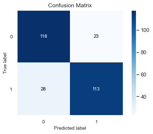

```python
skpmetrics.plot_confusion_matrix(y_test,y_pred);
```

```python
bp.show_methods(skpmetrics,contains='curve')
```

|  | 0 | 1 | 2 |
| --- | --- | --- | --- |
| 0 | binary_ks_curve | plot_calibration_curve | plot_roc_curve |
| 1 | calibration_curve | plot_lift_curve | precision_recall_curve |
| 2 | cumulative_gain_curve | plot_precision_recall_curve | roc_curve |

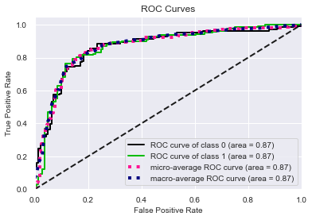

```python
y_prob2d = np.c_[1-y_prob1d, y_prob1d]
skpmetrics.plot_roc(y_test, y_prob2d );
```

# Time Taken

```python
time_taken = time.time() - time_start_notebook
h,m = divmod(time_taken,60*60)
print('Time taken to run whole notebook: {:.0f} hr '\
      '{:.0f} min {:.0f} secs'.format(h, *divmod(m,60)))
```

```
Time taken to run whole notebook: 0 hr 0 min 8 secs
```